# group21_ final

```r
rm(list=ls(all=T))
Sys.setlocale("LC_TIME","C")
```

```
## [1] "C"
```

```r
pacman::p_load(magrittr, readr, caTools, ggplot2, dplyr,d3heatmap,ggmap,mapproj,maps,maptools,splancs)
```

```r
Z = read_csv("ta_feng_all_months_merged.csv") %>% data.frame %>%
  setNames(c("date","cust","age","area","cat","prod","qty","cost","price"))
Z$date = as.Date(as.character(Z$date),format="%m/%d/%Y")
```

##### 彙總訂單 Assign Transaction ID

```r
Z$tid = group_indices(Z, date, cust) # same customer same day
```

##### 資料總覽

```r
# No. cust, cat, prod, tid
sapply(Z[c("cust","cat","prod","tid")], n_distinct)
```

```
##   cust    cat   prod    tid
##  32266   2012  23812 119578
```

```r
# n_distinct 看資料欄位中有多少不一樣的值 tid是指有多少訂單 平均一個顧客有3張訂單
```

##### 顧客資料彙整

##### 顧客摘要

### 一、經營現況

### `購買頻率與售價關係`

```r
a = table(Z$prod)%>%sort %>% as.data.frame()
z = merge(Z, a, by.x = "prod", by.y = "Var1")
z3 = subset(z, z$Freq > 1500)
z2 = subset(z, z$qty == 1)
```

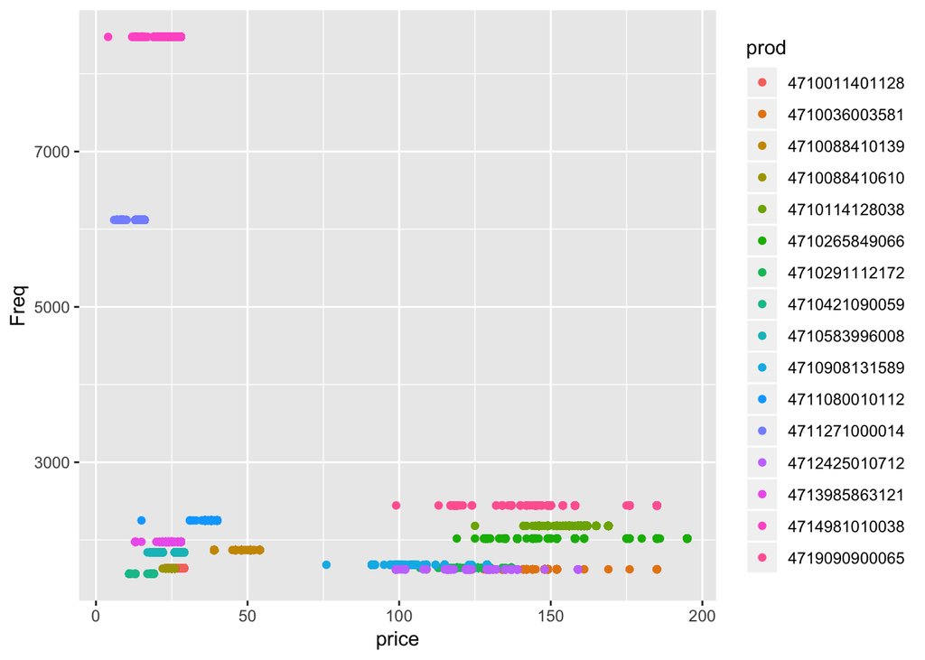

```r
z3a = subset(z3, z3$qty == 1)
ggplot(z3a, aes(x = price, y = Freq, color =prod)) + geom_point()
```

++我們將購買頻率超過1500次的商品歸類為「熱門商品」，從圖中可以看出16項最熱門商品的售價介於0~200元之間，從價錢推測可能是食品類、日常生活用品等

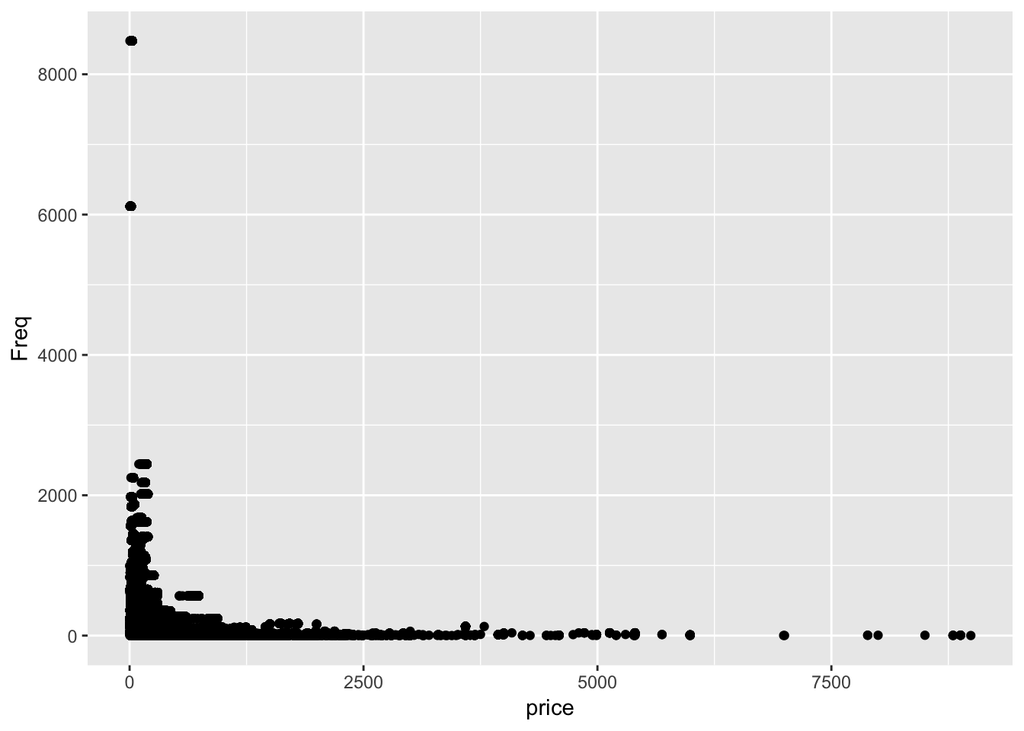

```r
z2 = subset(z, z$qty == 1)
ggplot(z2, aes(x = price, y = Freq)) + geom_point()
```

++從購買頻率與售價關係圖中，可以看出大豐雜貨店的主要訂單來自2000元以下的商品，2000元以上的商品個筆訂單數量大致都不超過50筆

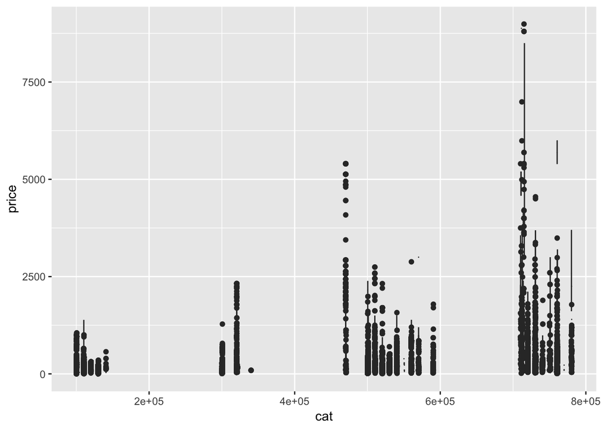

```r
ggplot(z2, aes(x=cat, y=price, group = cat)) +
  geom_boxplot()
```

++產品類別編號越小的商品價錢區間越小，應屬於食品、日常生活用品類，而編號越大的商品則可能屬於價差較大的家電、娛樂用品等

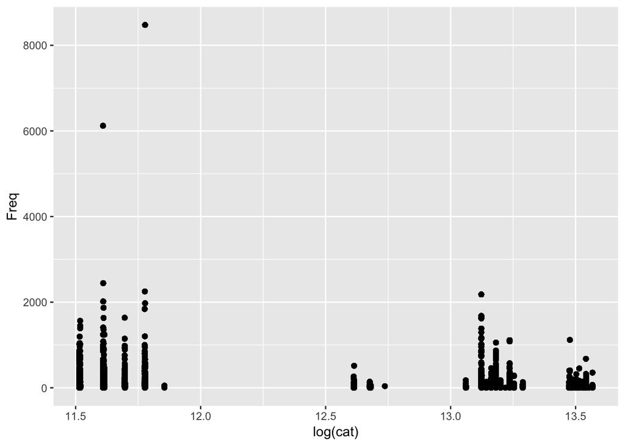

```r
ggplot(z2, aes(x = log(cat), y = Freq)) + geom_point()
```

++大致推測出產品類別編號越小的商品訂單購買次數越大，使用上較為頻繁

### 二、顧客分群

```r
# 資料格式轉換
Z$date = as.Date(Z$date, format="%m/%d/%Y")
Z$age[is.na(Z$age)] = "na"
Z$age = factor(Z$age, levels=c(
  "<25","25-29","30-34","35-39","40-44","45-49","50-54","55-59","60-64",">65","na"), labels=c(
  "20","25","30","35","40","45","50","55","60","65","na"
  )) %>% as.character
Z$area = paste0("z",Z$area)
```

##### 資料處理

```r
# Quantile of Variables
sapply(Z[,7:9], quantile, prob=c(.99, .999, .9995))
```

```
##        qty   cost   price
## 99%      6  858.0 1014.00
## 99.9%   14 2722.0 3135.82
## 99.95%  24 3799.3 3999.00
```

```r
# Remove Outliers
Z = subset(Z, qty<=24 & cost<=3800 & price<=4000)
Z$tid = group_indices(Z, date, cust) # same customer same day
# No. cust, cat, prod, tid
sapply(Z[c("cust","cat","prod","tid")], n_distinct)
```

```
##   cust    cat   prod    tid
##  32256   2007  23789 119422
```

```r
# n_distinct 看資料欄位中有多少不一樣的值 tid是指有多少訂單 平均一個顧客有3張訂單
```

##### 交易資料彙整

```r
X = Z %>% group_by(tid) %>% summarise(
  date = date[1],             # 交易日期
  cust = cust[1],             # 顧客 ID
  age = age[1],               # 顧客 年齡級別
  area = area[1],             # 顧客 居住區別
  items = n(),                # 交易項目(總)數
  pieces = sum(qty),          # 產品(總)件數
  total = sum(price),         # 交易(總)金額
  gross = sum(price - cost)   # 毛利
  ) %>% data.frame
#nrow(X) # 119422多筆訂單
#summary(X)
# Check Quantile & Remove Outliers
sapply(X[,6:9], quantile, prob=c(.999, .9995, .9999))
```

```
##        items   pieces     total    gross
## 99.9%     54  81.0000  9009.579 1824.737
## 99.95%    62  94.2895 10611.579 2179.817
## 99.99%    82 133.0000 16044.401 3226.548
```

```r
# Remove Outliers
X = subset(X, items<=62 & pieces<95 & total<16000)
```

##### 每周交易次數

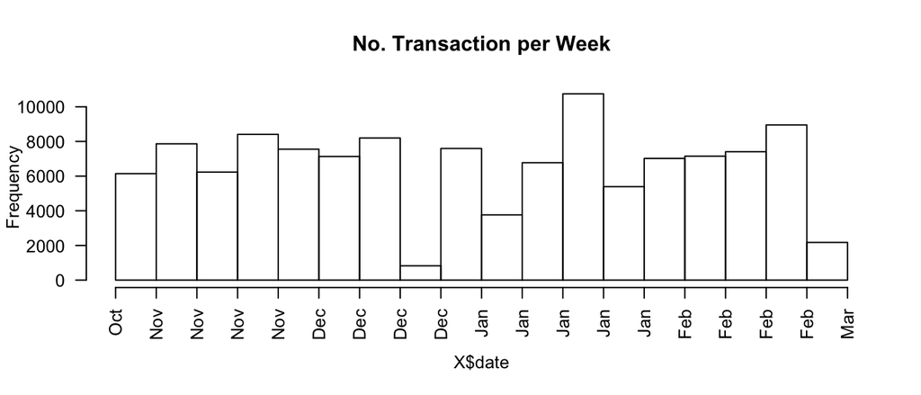

```r
par(cex=0.8)
hist(X$date, "weeks", freq=T, las=2, main="No. Transaction per Week")
```

##### 顧客資料彙整

```r
d0 = max(X$date) + 1
A = X %>% mutate(
  days = as.integer(difftime(d0, date, units="days"))
  ) %>%
  group_by(cust) %>% summarise(
    r = min(days),      # recency
    s = max(days),      # seniority
    f = n(),            # frquency
    m = mean(total),    # monetary
    rev = sum(total),   # total revenue contribution
    raw = sum(gross),   # total gross profit contribution
    age = age[1],       # age group
    area = area[1],     # area code
  ) %>% data.frame      # 33241多位顧客
#nrow(A)

#summary(A)
```

```r
# Check & Save
is.na(Z) %>% colSums
```

```
##  date  cust   age  area   cat  prod   qty  cost price   tid
##     0     0     0     0     0     0     0     0     0     0
```

```r
is.na(X) %>% colSums
```

```
##    tid   date   cust    age   area  items pieces  total  gross
##      0      0      0      0      0      0      0      0      0
```

```r
is.na(A) %>% colSums
```

```
## cust    r    s    f    m  rev  raw  age area
##    0    0    0    0    0    0    0    0    0
```

```r
A0 = A; X0 = X; Z0 = Z
save(Z0, X0, A0, file="tf0.rdata")
```

### `RFM顧客分群`

```r
#想換成數值，並加入分群資料Y中
age= as.numeric(A$age)
#age1為轉換成數值後的age, 但存在na

#A<-complete.cases(A)
is.na(A)%>%table
```

```
## .
##  FALSE
## 290169
```

```r
set.seed(111)
A$grp = kmeans(scale(A[,c(2,4,5)]),10)$cluster
table(A$grp)  # 族群大小
```

```
##
##    1    2    3    4    5    6    7    8    9   10
## 4719 1522 5210  425 8394 2738  489 2962 1840 3942
```

```r
#summary(A)
```

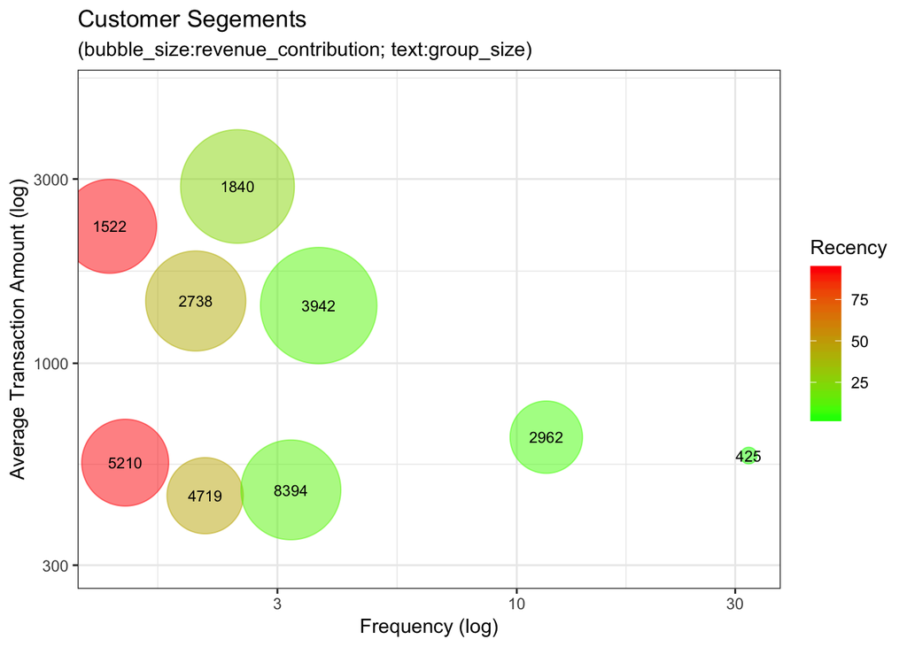

```r
#顧客群組屬性RFM
group_by(A, grp) %>% summarise(
  recent=mean(r),
  freq=mean(f),
  senior=mean(s), #考慮要不要放
  money=mean(m),
  size=n() ) %>%
  mutate( revenue = size*money/1000 )  %>%
  filter(size > 1) %>%
  ggplot(aes(x=freq, y=money)) +
  geom_point(aes(size=revenue, col=recent),alpha=0.5) +
  scale_size(range=c(4,30)) +
  scale_color_gradient(low="green",high="red") +
  scale_x_log10() + scale_y_log10(limits=c(300,5000)) +
  geom_text(aes(label = size ),size=3) +
  theme_bw() + guides(size=F) +
  labs(title="Customer Segements",
       subtitle="(bubble_size:revenue_contribution; text:group_size)",
       color="Recency") +
  xlab("Frequency (log)") + ylab("Average Transaction Amount (log)")
```

圖形解析：

- 將現有顧客分成十群，每個泡泡分別代表一群。
- 4種屬性，大小、顏色、X軸與Y軸可供判讀。
  - X軸：購買頻率。
  - Y軸：平均交易金額(客單價)。
  - 泡泡大小：反映這群顧客對你的營收貢獻。
  - 泡泡顏色：越紅就代表越久沒來買，可能快要流失了。
- 可以針對很常來買(頻率高)，買很少(客單價低)，去做行銷策略，擬定對這群顧客增加客單價的方法。

目標族群分析(依營收排序)：

[output not shown]

+我們根據最近來店天數、頻率，以及單筆消費金額等三個變數製作顧客分群圖表，並額外增加族群大小，及營收貢獻等資訊。 由顧客分群圖表，我們針對幾個具代表性、可作為目標族群的對象制定兩組行銷方案

- 目標族群
  - 目標族群Ａ：由1840、2738，以及3942三組人所組成的目標A，他們對總體的營收貢獻大，單筆消費金額高，我們希望能藉由提高目標族群的消費頻率，為雜貨店的收入帶來更進一步的改善
  - 目標族群Ｂ：目標B則針對右邊2962人所組成的群體，他們的消費頻率高，是雜貨店的忠實顧客，但是消費金額則較低，因此希望藉由提高他們的消費金額強化對店內營收的貢獻

```r
table(X$age, X$area) %>%
  as.data.frame.matrix%>%
  d3heatmap(F,F,col="Blues")
```

[interactive chart not shown]

+而地區及年齡的熱圖則告訴我們，來自南港的顧客最多，汐止次之，是我們最需要留住的客群信義的人數雖然不多，但顏色相較其他地區仍較明顯，屬於未來可以極力開拓的的客群。

### 三、行銷方案

### `行銷方案Ａ`

```r
#將日期加回資料框中
B = X %>%
  group_by(cust) %>% summarise(
    date = date[1],     # date
    f = n(),            # frquency
    m = mean(total),    # monetary
    rev = sum(total),   # total revenue contribution
    raw = sum(gross),   # total gross profit contribution
    age = age[1],       # age group
    area = area[1],     # area code
  ) %>% data.frame      # 33241多位顧客
nrow(B)
```

```
## [1] 32241
```

```r
#增加week欄位
week = format(B$date, format = "%a")
set.seed(111)
grp = kmeans(scale(A[,c(2,4,5)]),10)$cluster
B = mutate(B,grp,week)
B$grp = as.character(B$grp)
summary(B)
```

```
##      cust                date                  f
##  Length:32241       Min.   :2000-11-01   Min.   : 1.000
##  Class :character   1st Qu.:2000-11-11   1st Qu.: 1.000
##  Mode  :character   Median :2000-11-29   Median : 2.000
##                     Mean   :2000-12-10   Mean   : 3.701
##                     3rd Qu.:2001-01-04   3rd Qu.: 4.000
##                     Max.   :2001-02-28   Max.   :85.000
##        m                rev              raw              age
##  Min.   :    8.0   Min.   :     8   Min.   : -784.0   Length:32241
##  1st Qu.:  365.0   1st Qu.:   707   1st Qu.:   75.0   Class :character
##  Median :  705.7   Median :  1750   Median :  241.0   Mode  :character
##  Mean   :  993.1   Mean   :  3152   Mean   :  484.6
##  3rd Qu.: 1291.0   3rd Qu.:  3968   3rd Qu.:  612.0
##  Max.   :12636.0   Max.   :127686   Max.   :20273.0
##      area               grp                week
##  Length:32241       Length:32241       Length:32241
##  Class :character   Class :character   Class :character
##  Mode  :character   Mode  :character   Mode  :character
##
##
##
```

```r
#設定目標族群
target = B$target
B = mutate(B,target)
to_Increase_frequency =c("6","9","10")
B$target[B$grp %in% to_Increase_frequency] = TRUE
B$target[B$grp %in% c("1","2","3","4","5","7","8","na")] = FALSE


#取出目標族群的子集
B_weekdis = subset(B,B$grp %in% to_Increase_frequency )
B_weekdis$grp = factor(B_weekdis$grp, levels=c("6","9","10"),labels=c("2738","1840","3942"))

nrow(B_weekdis)                                   #8520人
```

```
## [1] 8520
```

```r
summary(B_weekdis)
```

```
##      cust                date                  f                m
##  Length:8520        Min.   :2000-11-01   Min.   : 1.000   Min.   : 867.1
##  Class :character   1st Qu.:2000-11-16   1st Qu.: 1.000   1st Qu.:1190.5
##  Mode  :character   Median :2000-12-08   Median : 2.000   Median :1517.2
##                     Mean   :2000-12-17   Mean   : 2.878   Mean   :1738.5
##                     3rd Qu.:2001-01-20   3rd Qu.: 4.000   3rd Qu.:2093.0
##                     Max.   :2001-02-28   Max.   :12.000   Max.   :4392.0
##       rev             raw             age                area
##  Min.   :  912   Min.   :-647.0   Length:8520        Length:8520
##  1st Qu.: 2220   1st Qu.: 323.0   Class :character   Class :character
##  Median : 3842   Median : 605.0   Mode  :character   Mode  :character
##  Mean   : 4842   Mean   : 793.4
##  3rd Qu.: 6276   3rd Qu.:1046.0
##  Max.   :47061   Max.   :9371.0
##    grp           week            target
##  2738:2738   Length:8520        Mode:logical
##  1840:1840   Class :character   TRUE:8520
##  3942:3942   Mode  :character
##
##
##
```

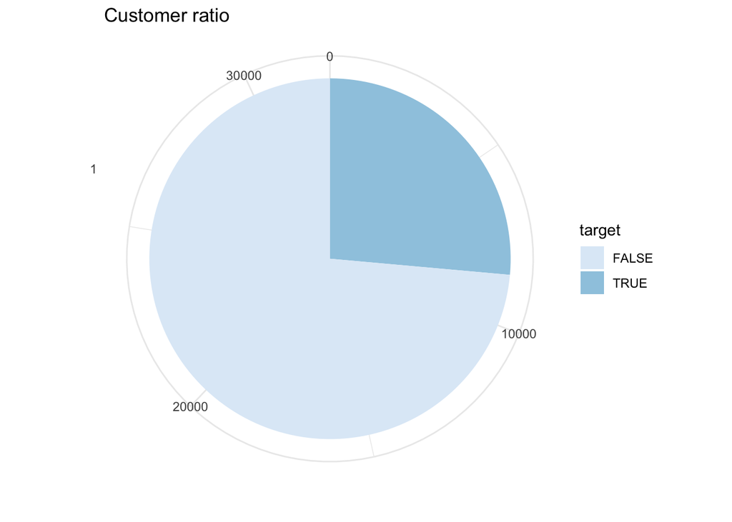

```r
#高單價低頻率族群佔所有顧客與營收的比率
peorat = nrow(B_weekdis)/nrow(B)                  #所佔顧客比26.4%
ggplot(B, aes(x=factor(1), fill=target))+
  geom_bar(width = 1)+
  coord_polar("y", start = 0)+
  labs(x="", y="", title = "Customer ratio")+
  scale_fill_brewer(palette = "Blues")+
  theme_minimal()
```

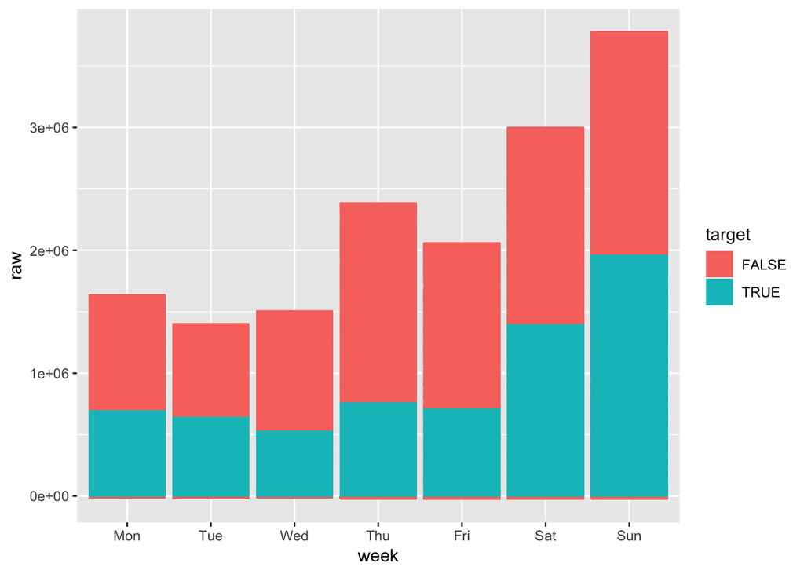

```r
rawrat = (793.4*8520)/(484.6*32241)               #所佔營收比43.3%
B$week =factor(B$week, levels=c("Mon","Tue","Wed","Thu","Fri","Sat","Sun"))
ggplot(B,aes(x =week, y = raw, fill= target, col = target))+
  geom_bar(stat="identity", position="stack")
```

```
+ 1：平日促銷：由於目標客群多在假日消費，若是能結合平日信用卡優惠、推出每日促銷商品，誘使顧客提高平日來店消費的動機
+ 2：VIP每月來店禮：雖然目標客群來店的頻率較低，但是單筆購買金額高，我們建議商家推出VIP方案，不只提高顧客黏著度，更能以每月來店禮為由，提高VIP客群來店的機會
+ 3：限定期間的集點換贈活動：推出每月期間限定的集點換贈活動，達到特定金額即可兌換贈品，鼓勵目標客群在限定期間內來店購物，達到提高消費頻率的效果
+ 4:線下結合線上，加入電商平台：由於目標客群多為中壯年族群，是家庭經濟來源的提供者，週一至週五需要工作，限制了平日來店消費的機會，若是店家加入電商平台則可以模糊購物時間和空間上的限制
```

### `行銷方案 B`

```r
set.seed(111)

A = X %>% mutate(
  days = as.integer(difftime(d0, date, units="days"))
  ) %>%
  group_by(cust) %>% summarise(
    r = min(days),      # recency
    s = max(days),      # seniority
    f = n(),            # frquency
    m = mean(total),    # monetary
    rev = sum(total),   # total revenue contribution
    raw = sum(gross),   # total gross profit contribution
    age = age[1],       # age group
    area = area[1],     # area code
    items = items[1],
    pieces = pieces[1]
  ) %>% data.frame

A$grp = kmeans(scale(A[,c(2,4,5)]),10)$cluster
table(A$grp)  # 族群大小
```

```
##
##    1    2    3    4    5    6    7    8    9   10
## 4719 1522 5210  425 8394 2738  489 2962 1840 3942
```

```r
C=unique(A[,c(1,2,3,5:12)])  %>% left_join(Z[,c(1,2,5:9)],by = "cust")

C05= filter(C, grp==5)
C08= filter(C, grp==8)
```

```r
C08 %>% group_by(cat) %>% summarise(
  mean(price),
  profit = sum(price-cost),
  prod[1]
) %>% arrange(desc(profit)) %>% head(10)
```

```
## # A tibble: 10 x 4
##       cat `mean(price)` profit `prod[1]`
##     <dbl>         <dbl>  <dbl> <chr>
##  1 320402        1123.   65498 20546786
##  2 560201         507.   55459 4710054503315
##  3 560402         663.   51419 4710043004113
##  4 100205          57.7  45017 4901005132702
##  5 130206          74.9  39913 20557003
##  6 530101         104.   36645 4710036000719
##  7 130204          86.4  32192 4710063312168
##  8 530110         197.   31659 4710094020803
##  9 110401          59.4  30081 4710088410139
## 10 100102          92.1  29472 0034000102112
```

```r
C08 %>% group_by(prod) %>% summarise(
  cat[1],
  price[1],
  profit = sum(price-cost)
) %>% arrange(desc(profit)) %>% head(10)
```

```
## # A tibble: 10 x 4
##    prod          `cat[1]` `price[1]` profit
##    <chr>            <dbl>      <dbl>  <dbl>
##  1 4909978112950   470103       1800  12023
##  2 20564100        320402       1180   7380
##  3 4901422038939   500307        159   6385
##  4 20556433        320402       1242   5905
##  5 4710043552102   110109        181   5381
##  6 4710114128038   500201        146   5297
##  7 20559045        730719       1700   5190
##  8 4902430493437   560201        558   5002
##  9 7610053910787   560201        678   4786
## 10 4711080010112   130206         40   4558
```

#####行銷目標 + 目標客群：族群8，2962族群 + 主要來店時段：六、日 + 居住地：集中在南港與汐止區，在這兩區的年齡層分布多為35-45區間 + 35-45區間的人多集中於假日消費，來店頻率高

#####行銷方案 ”320402“產品品項為族群8中獲利偏高之產品（排名2&4），其產品類別亦屬於此族群中的第一大產品類別，又此產品的定價落在一千初左右，將此產品類別假設為酒類產品 “560201”產品品項定價約落於500元，架設此顫品類別為開架式美妝產品，且集中於美髮、美體產品。

在本通路中，`假設熱銷產品為酒類產品與美容產品`，皆屬於消費者偏好前往實體通路會購買的產品，皆為毛利與單價較高的產品類別，因此在目標族群（族群8）中，為提高客單價，可從這兩項產品著手進行。

**提高客單價之行銷手段** `1. 結帳窗口加價購服務` 酒類：購買酒類產品單筆訂單達3999，即可加價120購買一支紅酒杯 美容：美容美髮美體產品單筆消費滿2000，以690加價購買2小時指定spa療程 `2. 滿額禮`：針對酒類產品，單筆消費滿12,000，送餐酒館禮卷1客，價值800，數量有限。 `3. 平日促銷`：由於目標族群8之消費多集中於假日，為了提高平日的銷售，在平日推出產品促銷方案，搭配指定信用卡，購買酒類與美容產品皆打8折優惠。 `4. 體驗活動`：針對美妝產品，邀請專業美容師，舉辦現場體驗贈送試用包，並且消費者在體驗後可以優惠價格組合選購產品。 `5. 提供便利購服務`：針對酒類產品，單筆訂單滿2000，至店裡消費亦可宅配到家免運費。

### 四、預期成效

```r
#載入資料
G<-read_csv("ta_feng_all_months_merged.csv")
#轉換日期:整理日期、+上weekday、+上月份
G$TRANSACTION_DT<-as.Date(G$TRANSACTION_DT,format="%m/%d/%Y")
G<-G%>%mutate(wday=format(G$TRANSACTION_DT,"%u"))
G<-G%>%mutate(month=format(G$TRANSACTION_DT,"%B"))

#查看資料
#str(G)
#summary(G)
table(G$AGE_GROUP)
```

```
##
##    <25    >65  25-29  30-34  35-39  40-44  45-49  50-54  55-59  60-64
##  30070  27353  66432 140805 181213 151023  99719  53719  24743  20302
```

```r
levels(G$AGE_GROUP)=c(1:11)

table(G$PIN_CODE)
```

```
##
##     105     106     110     114     115     221  Others Unknown
##   17243   19712   71640   38674  312501  245213   72092   40666
```

```r
duplicated(G$TRANSACTION_DT)%>%table
```

```
## .
##  FALSE   TRUE
##    120 817621
```

```r
table(G$wday)
```

```
##
##      1      2      3      4      5      6      7
## 107468  91090  85942  90158  89519 151183 202381
```

```r
table(G$month)
```

```
##
## December February  January November
##   178216   199039   216864   223622
```

```r
#重新設定名稱
G<-G%>%data.frame%>%
  set_colnames(c("date", "cid" , "age","area","cat","prod","qty","cost","price","wday","month"))
G[is.na(G)] = "na"
```

```r
#過濾極端直
sapply(G[7:9],quantile,prob=c(0.9,0.999,0.9995))
```

```
##        qty   cost   price
## 90%      2  201.0  239.00
## 99.9%   14 2722.0 3135.82
## 99.95%  24 3799.3 3999.00
```

```r
G<-subset(G,qty<=24&cost<=3800 & price<=4000)
#彙總訂單 查看同一個顧客再特定一天內購買物
G$tid<-group_indices(G,date,cid)
```

交易紀錄整理

```r
D<-G %>% group_by(tid)%>% summarize(
  date = date[1],
  cid = cid[1],
  age = age[1],
  area = area[1],
  items = n(),
  pieces = sum(qty),
  total = sum(price),
  gross = sum(price - cost)
  ) %>% data.frame
#削去離群直
sapply(D[6:9],quantile,prob=c(0.99,0.999,0.9995))
```

```
##        items  pieces     total    gross
## 99%       33 46.0000  4972.580  960.000
## 99.9%     54 81.0000  9009.579 1824.737
## 99.95%    62 94.2895 10611.579 2179.817
```

```r
D<-subset(D,items<=62&pieces<95&total<16000)
```

顧客資料

```r
d0<-max(G$date)+1
C<-D%>%mutate(days=as.integer(difftime(d0,date),units="days"))%>%
  group_by(cid) %>% summarise(
    r = min(days),      #近期使用日期
    s = max(days),      # 年資
    f = n(),            # 購買的個數
    m = mean(total),    # 平均金額
    rev = sum(total),   # 總金額
    gros = sum(gross),   # 總毛利
    age = age[1],       # 年齡
    area = area[1],     # 位置
     ) %>% data.frame

set.seed(111) #有問題???
C$grp = kmeans(scale(C[,c(2,4,5)]),10)$cluster
table(C$grp)
```

```
##
##    1    2    3    4    5    6    7    8    9   10
## 4719 1522 5210  425 8394 2738  489 2962 1840 3942
```

分割預測變數與目標變數 預測變數

```r
feb<-as.Date("2001-02-01")
X0<-subset(G,date<feb)
```

交易紀錄

```r
D1<- group_by(X0,tid)%>% summarize(
 date = first(date),  # 交易日期
  cid = first(cid),  # 顧客 ID
  age = first(age),    # 顧客 年齡級別
  area = first(area),  # 顧客 居住區別
  items = n(),                # 交易項目(總)數
  pieces = sum(qty),          # 產品(總)件數
  total = sum(price),         # 交易(總)金額
  gross = sum(price - cost)   # 毛利
  ) %>% data.frame
```

移出outlier

```r
sapply(D1[6:8],quantile,prob=c(0.99,0.999,0.9995))
```

```
##        items pieces     total
## 99%       33     47  5177.280
## 99.9%     56     84  9378.684
## 99.95%    64     98 11261.751
```

```r
D1<-subset(D1,items<=64&pieces<=98&total<=11260)
```

建立顧客資料

```r
d0<-max(D1$date)+1
C1<-D1%>%mutate(days=as.integer(difftime(d0,date),units="days"))%>%
  group_by(cid) %>% summarise(
    r = min(days),      #近期使用日期
    s = max(days),      # 年資
    f = n(),            # 購買的個數
    m = mean(total),    # 平均金額
    rev = sum(total),   # 總金額
    gros = sum(gross),   # 總毛利
    age = age[1],       # 年齡
    area = area[1] ,     # 位置
     ) %>% data.frame
```

目標變數 <1>

```r
Y1<-filter(D,date>=feb)%>%group_by(cid)%>%summarize(
  amount=sum(total))
```

彙整

```r
X<-merge(C1,Y1,by="cid",all.x=T)
```

找出未來買過的人

```r
table(is.na(X$amount))
```

```
##
## FALSE  TRUE
## 13242 15342
```

```r
X$buy<-!is.na(X$amount)
```

建立Buy模型與數量模型的TR TS 1.Buy模型

```r
X1<-subset(D1, cid %in% X$cid & date < as.Date("2001-02-01"))
G1<-subset(G,cid %in% X$cid&date<as.Date("2001-02-01"))
set.seed(2018); spl = sample.split(X$buy, SplitRatio=0.7)
#c(nrow(C1), sum(spl), sum(!spl))
```

2.數量模型

```r
X2<-subset(X,buy) %>% mutate_at(c("m","rev","amount"), log10)
n=nrow(X2)
set.seed(2018); spl2 <- 1:n %in% sample(1:n, round(0.7*n))
#c(nrow(X2), sum(spl2), sum(!spl2))
```

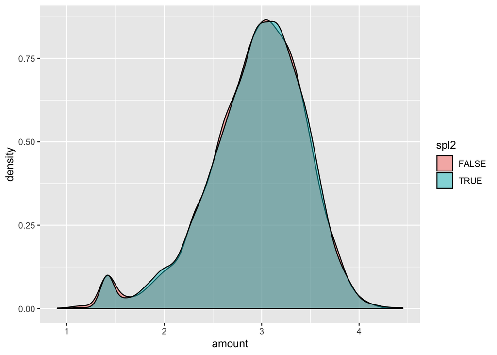

```r
cbind(X2, spl2) %>%
  ggplot(aes(x=amount)) + geom_density(aes(fill=spl2), alpha=0.5)
```

#——————————————————————– 命名TRTS

```r
TR = subset(X, spl)
TS = subset(X, !spl)
```

建立Buy回歸

```r
glm1<-glm(buy~.,TR[,c(2:6,8,9,11)],family=binomial)
pred=predict(glm1,TS,type="response")
cm=table(actual=TS$buy,predict=pred>0.5);cm
```

```
##        predict
## actual  FALSE TRUE
##   FALSE  3728  875
##   TRUE   1696 2277
```

ACC精準度

```r
acc.ts = cm %>% {sum(diag(.))/sum(.)}; acc.ts
```

```
## [1] 0.7002099
```

AUC辨識度

```r
colAUC(pred, TS$buy)
```

```
##                     [,1]
## FALSE vs. TRUE 0.7548735
```

數量模型

```r
X2 = subset(X, X$buy) %>% mutate_at(c("m","rev","amount"), log10)
TR1=subset(X2,spl2)
TS1=subset(X2,!spl2)
```

```r
glm2<-lm(amount~.,TR1[,c(2:6,8:10)])
```

計算R-square

```r
r2.tr = summary(glm2)$r.sq
SST = sum((TS1$amount - mean(TR1$amount))^ 2)
SSE = sum((predict(glm2, TS1) -  TS1$amount)^2)
r2.ts = 1 - (SSE/SST)
#c(r2.tr, r2.ts)
```

### Prediction

```r
d0 = max(X1$date) + 1
B = X1 %>%
  filter(date >= as.Date("2000-12-01")) %>%
  mutate(days = as.integer(difftime(d0, date, units="days"))) %>%
  group_by(cid) %>% summarise(
    r = min(days),      # recency
    s = max(days),      # seniority
    f = n(),            # frquency
    m = mean(total),    # monetary
    rev = sum(total),   # total revenue contribution
    raw = sum(gross),   # total gross profit contribution
    age = age[1],       # age group
    area = area[1],     # area code
  ) %>% data.frame      # 28584
#nrow(B)
```

```r
B$Buy = predict(glm1, B, type="response")
```

```r
B$Rev = predict(glm2, B)
```

預測後的特徵變化

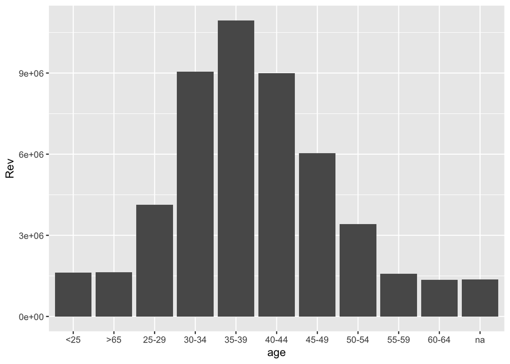

```r
a<-B%>%group_by(age)%>%
  summarize(
    Rev=sum(rev)
  )
ggplot(a,aes(age,Rev))+geom_bar(stat="identity",ylim=c(1000000,15000000))
```

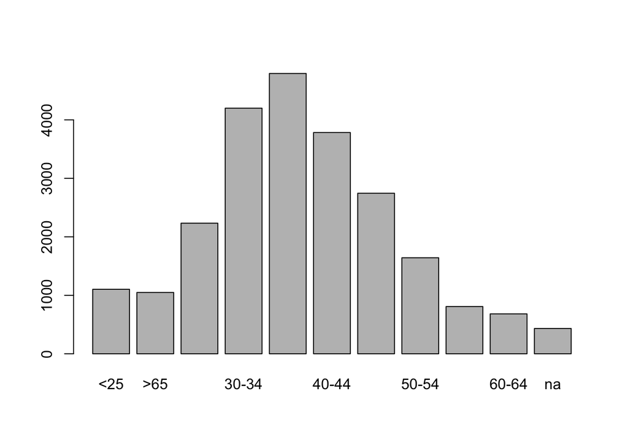

```r
B$age%>%table%>%barplot
```

預期購買的機率分布

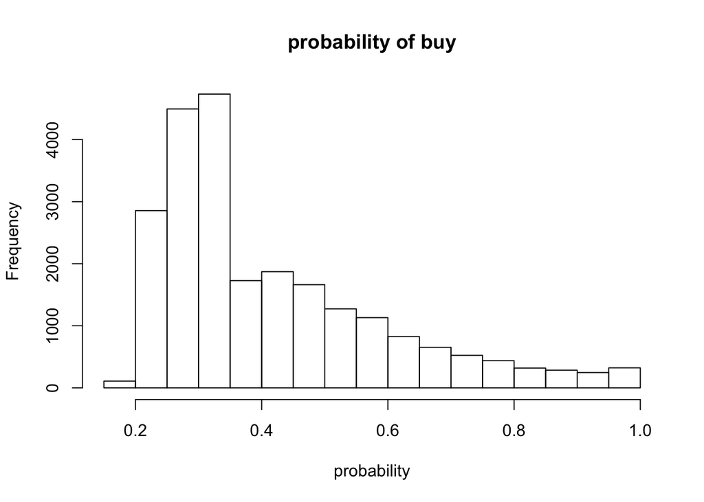

```r
hist(B$Buy,main="probability of buy",xlab="probability")
```

每個單位的行銷成本為100，行銷效益為0.8

```r
cost=100
effect=0.8

target<-left_join(B,C,by="cid")
mean(target$Buy)
```

```
## [1] 0.4135324
```

```r
mean(target$Rev)
```

```
## [1] 608.5263
```

```r
target<-left_join(B,C,by="cid")
target<-subset(target,target$grp==8)
target$ExpReturn = (effect - target$Buy  ) * target$Rev - cost
mean(target$ExpReturn)
```

```
## [1] -55.2528
```

```r
summary(target$ExpReturn)
```

```
##    Min. 1st Qu.  Median    Mean 3rd Qu.    Max.
## -522.98 -100.19  -69.42  -55.25  -24.31  636.04
```

+我們針對方案 B進行行銷預期報酬的推算。我們設定每單位行銷成本為100元，預估效益0.8， 可以看到總平均落在-55.2528，這項結果讓我們知道行銷策略B對於目標族群的預計報酬為負值。

```r
target %>% arrange(desc(ExpReturn)) %>% select(cid, ExpReturn) %>% head(15)
```

```
##         cid ExpReturn
## 1  02056012  636.0425
## 2  01771756  533.0313
## 3  01704723  508.0560
## 4  02033808  454.9691
## 5  01983333  443.7302
## 6  02037820  441.3043
## 7  00765350  427.1661
## 8  01196139  411.4887
## 9  02145648  409.2934
## 10 02040677  367.4948
## 11 00902267  364.2197
## 12 01497373  358.7272
## 13 02125046  335.4040
## 14 01948097  330.6319
## 15 01568448  324.8747
```

```r
sum(target$ExpReturn > 0)
```

```
## [1] 521
```

```r
sum(target$ExpReturn[target$ExpReturn > 0])
```

```
## [1] 43102.13
```

+不要緊張！！ 雖然對於整個目標族群可能會是負值。 但透過排序看到，前10高的消費者，預期報酬至少都高達360以上，最高更可能超過600，仍然是有利可圖的。 所以，我們只要將目標族群劃分的更細，將預期報酬較大的對象挑選出來，就能達到最大的效益。 +在實務上， 我們可以找出這521個預期報酬大於零的顧客，並針對他們推廣行銷， 就可能得到高達4萬三千元的預期報酬。